# Causal Inference in the Social Sciences

A Design-First Introduction

Zach Dickson

Fellow in Quantitative Methodology  
London School of Economics

# Schedule

| Time | Block |
| --- | --- |
| 10:00–10:50 | **1. Foundations:** potential outcomes and the fundamental problem |
| 10:50–11:00 | *Break* |
| 11:00–11:30 | **2a. Experiments:** why randomization works |
| 11:30–12:00 | **2b. Lab 1:** simulating potential outcomes and randomization |
| 12:00–13:00 | *Lunch* |
| 13:00–13:50 | **3a. Observational studies:** DAGs and designs that mimic experiments |
| 13:50–14:20 | **3b. Lab 2:** difference-in-differences |
| 14:20–14:30 | *Break* |
| 14:30–15:00 | **4. Advanced topics** and wrap-up |

Core text: Huntington-Klein, [*The Effect*](https://theeffectbook.net) (free online)

# My Background & Research Interests

# Today’s goals

By the end of today you should be able to:

1. Turn a research question into a **causal question** with a clear counterfactual
2. Explain the **fundamental problem of causal inference** and **selection bias**
3. Explain **why randomization works**, and what can go wrong in experiments
4. Use **DAGs** to state your assumptions
5. Explain the key assumption behind **DiD, RD and IV**, and run a simple DiD

# Part 1 Foundations

01Foundations02Experiments03Observational studies04Advanced topics

Potential outcomes, counterfactuals and the fundamental problem

# Correlation vs. Causation

01Foundations02Experiments03Observational studies04Advanced topics

[figure not shown]

# What makes a question *causal*?

01Foundations02Experiments03Observational studies04Advanced topics

- **Descriptive:** How many people voted in the 2024 UK general election?
- **Predictive:** Which constituencies are likely to swing at the next election?
- **Causal:** Does receiving a canvassing visit *make* people more likely to vote?
- Causal questions are about **interventions**: what would happen if we *changed* something?
- Most of the questions social scientists care about are causal, even when we don’t say so (“the effect of”, “leads to”, “increases”, “explains”)

# Counterfactual Thinking

01Foundations02Experiments03Observational studies04Advanced topics

- A causal effect is a comparison between **two states of the world**:
  - the world where the treatment happened, and
  - the world where it **didn’t**: the **counterfactual**
- **Example:**
  - Maya takes part in a civic education programme, and then votes in every election.
  - **Counterfactual:** Would Maya have voted anyway, *without* the programme?
- The causal effect is the difference between those two worlds, *for the same person at the same time*.

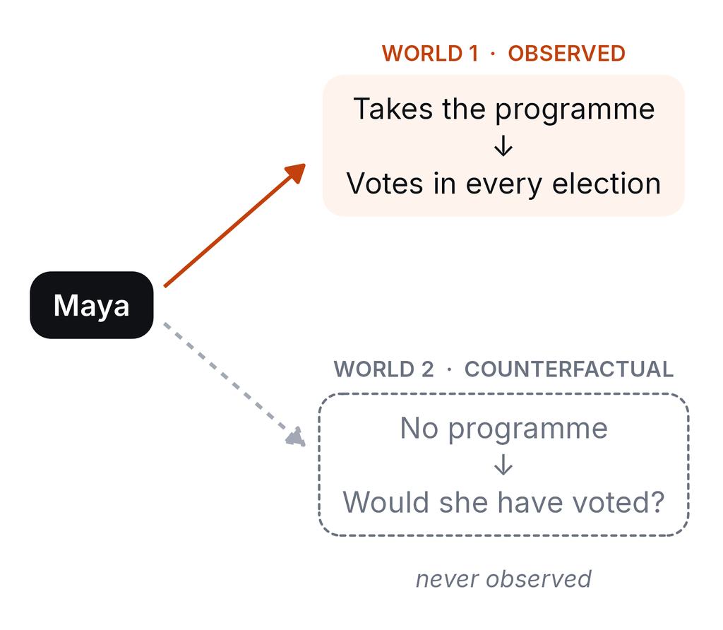

# The Potential Outcomes Framework

01Foundations02Experiments03Observational studies04Advanced topics

- **Treatment** $D_i$ for unit $i$:
  - $D_i = 1$: treated
  - $D_i = 0$: not treated (control)
- **Potential outcomes**, defined *before* treatment is assigned:
  - $Y_i(1)$: the outcome unit $i$ *would* have if treated
  - $Y_i(0)$: the outcome unit $i$ *would* have if not treated
- **Individual treatment effect:**

$$\tau_i = Y_i(1) - Y_i(0)$$

# A world where we can see everything

01Foundations02Experiments03Observational studies04Advanced topics

Does a civic education programme increase political participation (0–100 score)?

| Unit | Prior interest | $Y_i(0)$ | $Y_i(1)$ | $\tau_i$ |
| --- | --- | --- | --- | --- |
| 1 | High | 60 | 65 | 5 |
| 2 | High | 70 | 72 | 2 |
| 3 | High | 55 | 63 | 8 |
| 4 | Low | 40 | 46 | 6 |
| 5 | Low | 35 | 39 | 4 |
| 6 | Low | 30 | 35 | 5 |

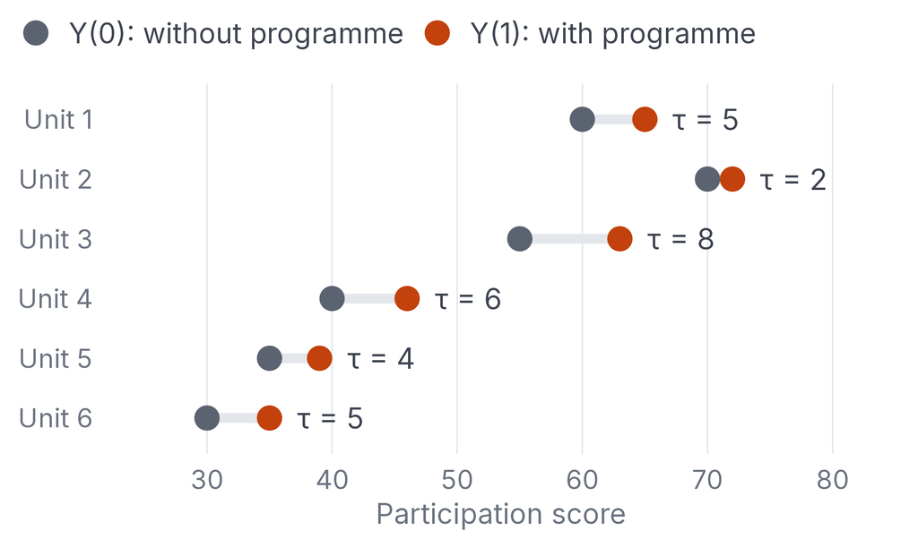

- Effects differ from person to person (**heterogeneity**)
- The **average treatment effect**: $ATE = E[Y_i(1) - Y_i(0)] = \frac{5+2+8+6+4+5}{6} = 5$

# The Fundamental Problem of Causal Inference

01Foundations02Experiments03Observational studies04Advanced topics

- Each unit is either treated **or** not, never both.
- So we only ever observe **one** potential outcome per unit:

$$Y_i = D_i \cdot Y_i(1) + (1 - D_i) \cdot Y_i(0)$$

- The other potential outcome is the **counterfactual**, and it is **missing**.
- Causal inference is a **missing data problem**.

# What we actually see

01Foundations02Experiments03Observational studies04Advanced topics

Suppose people **choose** whether to take the programme, and the politically interested sign up:

| Unit | Prior interest | $D_i$ | $Y_i(0)$ | $Y_i(1)$ | $\tau_i$ |
| --- | --- | --- | --- | --- | --- |
| 1 | High | 1 | **?** | 65 | **?** |
| 2 | High | 1 | **?** | 72 | **?** |
| 3 | High | 1 | **?** | 63 | **?** |
| 4 | Low | 0 | 40 | **?** | **?** |
| 5 | Low | 0 | 35 | **?** | **?** |
| 6 | Low | 0 | 30 | **?** | **?** |

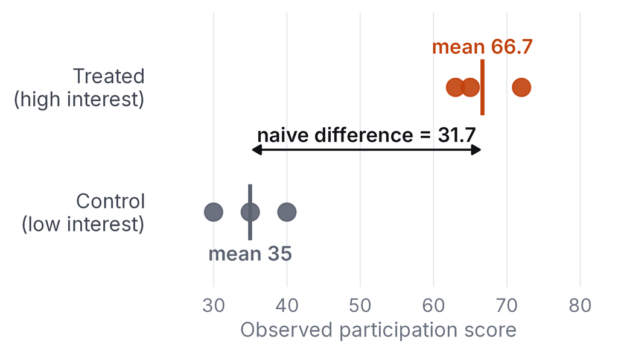

- We **cannot** compute any individual effect.
- We **can** compare averages: treated mean $= 66.7$, control mean $= 35$.
- Naive difference $= 31.7$. But the true ATE is $5$!

# What are we trying to estimate?

01Foundations02Experiments03Observational studies04Advanced topics

Before estimating anything, be clear about the **estimand**: the causal quantity you want.

- **ATE** (average treatment effect): the average effect for **everyone**
  - $ATE = E[Y_i(1) - Y_i(0)]$
- **ATT** (average treatment effect on the treated): the average effect for **those who got treated**
  - $ATT = E[Y_i(1) - Y_i(0) \mid D_i = 1]$
- **ATU** (average treatment effect on the untreated): the average effect for **those who didn’t**
  - $ATU = E[Y_i(1) - Y_i(0) \mid D_i = 0]$
- In our example: $ATT = \frac{5+2+8}{3} = 5$, $ATU = \frac{6+4+5}{3} = 5$. Here they coincide, but in general they **differ** (e.g. if those who benefit most are the ones who sign up)

# Why the naive comparison fails

01Foundations02Experiments03Observational studies04Advanced topics

The naive difference in means can be split into two parts:

$$\underbrace{E[Y_i \mid D_i{=}1] - E[Y_i \mid D_i{=}0]}_{\text{naive difference}}
= \underbrace{E[Y_i(1) - Y_i(0) \mid D_i{=}1]}_{\text{ATT}}
+ \underbrace{E[Y_i(0) \mid D_i{=}1] - E[Y_i(0) \mid D_i{=}0]}_{\text{selection bias}}$$

In our example:

$$\underbrace{31.7}_{\text{naive}} = \underbrace{5}_{\text{ATT}} + \underbrace{(61.7 - 35)}_{\text{selection bias} \; = \; 26.7}$$

**Selection bias:** the treated group would have had different outcomes **even without treatment**. Interested people participate more, programme or not.

# How can we approximate the counterfactual?

01Foundations02Experiments03Observational studies04Advanced topics

- We need a comparison group whose outcomes tell us what would have happened to the treated group **without treatment**.
- That requires the groups to be comparable: $E[Y_i(0) \mid D_i{=}1] = E[Y_i(0) \mid D_i{=}0]$
- **Every research design in this workshop is a strategy for making this plausible.**

# The Experimental Ideal

01Foundations02Experiments03Observational studies04Advanced topics

Imagine you had unlimited money and power. What study would you run to answer your question?

- You would control **who gets treated**.
- You would make sure treatment has **nothing to do with** anything that affects the outcome.
- The simplest way to do that: **flip a coin**.
- Thinking about the ideal experiment, even an impossible one, clarifies:
  - the **treatment**, the **outcome**, the **unit** and the **counterfactual**
  - what your actual design needs to approximate

# Activity: Your causal question (3 min)

01Foundations02Experiments03Observational studies04Advanced topics

With the person next to you:

1. Write down a **causal question** from your own research (or one that interests you).
2. What is the **unit**, the **treatment** and the **outcome**?
3. What is the **counterfactual**?
4. Describe the **ideal experiment**. Why can’t (or can) you run it?
5. If you just compared treated and untreated units, which way would **selection bias** go?

# Summary: Foundations

01Foundations02Experiments03Observational studies04Advanced topics

- Causal effects are comparisons of **potential outcomes**: $Y_i(1)$ vs. $Y_i(0)$
- **Fundamental problem:** we only ever see one of them
- Be clear about your **estimand** (ATE, ATT, ATU)
- **Naive difference = ATT + selection bias**
- The **experimental ideal** is the benchmark for every design
- **Next:** how randomization makes selection bias disappear

# 10 minute break

📌 Questions? Feel free to ask!

# Part 2 Experiments

01Foundations02Experiments03Observational studies04Advanced topics

Why randomization works

# Why randomization works

01Foundations02Experiments03Observational studies04Advanced topics

- If treatment is assigned **at random**, it can’t be related to anything about the units, including their potential outcomes:

$$\big(Y_i(1), Y_i(0)\big) \perp D_i$$

- So, **on average**, the treatment and control groups are the same before treatment:

$$E[Y_i(0) \mid D_i{=}1] = E[Y_i(0) \mid D_i{=}0] \quad \Rightarrow \quad \text{selection bias} = 0$$

- And the simple difference in means estimates the **ATE**.

# Randomization balances *everything*

01Foundations02Experiments03Observational studies04Advanced topics

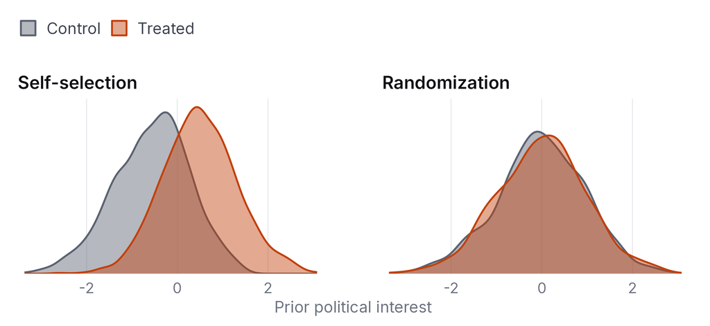

Randomization balances **observed and unobserved** characteristics: things we can measure, and things we can’t.

# Unbiased ≠ right every time

01Foundations02Experiments03Observational studies04Advanced topics

Back to our 6 units. There are 20 ways to randomly treat 3 of them:

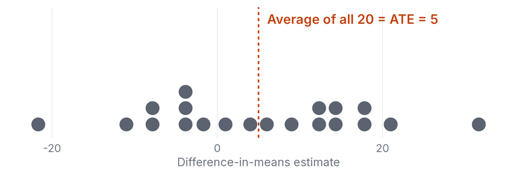

Randomization is **unbiased**: correct *on average* across possible assignments. Any one experiment has **chance variation** from who happens to be assigned, and bigger samples reduce it.

# Estimating effects in an experiment

01Foundations02Experiments03Observational studies04Advanced topics

- **Difference in means:** $\hat{\tau} = \bar{Y}_{\text{treated}} - \bar{Y}_{\text{control}}$
- Equivalently, a regression: $Y_i = \alpha + \tau D_i + \varepsilon_i$
- **Adding pre-treatment covariates:** $Y_i = \alpha + \tau D_i + \beta X_i + \varepsilon_i$
  - Not needed for **identification**: randomization already took care of that
  - But it can improve **precision** (smaller standard errors)
  - Only use variables measured **before** treatment
- **Balance checks:** compare pre-treatment covariates across groups to check the randomization worked

# Experiments in the social sciences

01Foundations02Experiments03Observational studies04Advanced topics

Lab experiments

Controlled setting, often with student samples

- e.g. economic games, decision-making studies

Field experiments

Real interventions in real settings

- e.g. get-out-the-vote campaigns, information interventions, audit studies

Survey experiments

Randomize *what respondents see* within a survey

- **Vignettes:** randomize details of a scenario
- **Conjoints:** randomize many attributes at once (e.g. candidate profiles)
- Cheap and scalable, but how well do they generalize to real behaviour?

# Example: Social pressure and turnout

01Foundations02Experiments03Observational studies04Advanced topics

Gerber, Green, and Larimer (2008) randomly assigned ~180,000 Michigan households to receive one of four mailings before the 2006 primary election (or nothing).

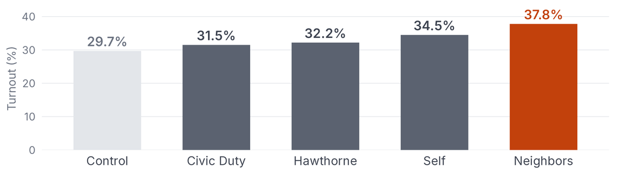

**Neighbors**: the mailing listed the household’s *and its neighbors’* past turnout, and promised an updated list after the election. This raised turnout by **8.1 percentage points**.

# What can go wrong in experiments?

01Foundations02Experiments03Observational studies04Advanced topics

- **Noncompliance:** people assigned to treatment don’t take it (or controls get it anyway)
- **Attrition:** people drop out, and dropping out may be related to treatment
- **Spillovers / interference:** one unit’s treatment affects another unit’s outcome
  - This violates **SUTVA** (the *Stable Unit Treatment Value Assumption*: no interference, no hidden versions of treatment)
  - e.g. a canvassed voter persuades their housemate
- **External validity:** does the effect generalize to other people, places or times?
- **Demand effects:** participants behave differently because they know they’re being studied

# Noncompliance: ITT and CACE

01Foundations02Experiments03Observational studies04Advanced topics

Suppose we **randomly invite** people to the programme ($Z_i$), but only some attend ($D_i$).

- **As-treated** (attenders vs. non-attenders): ❌ attendance is self-selected again
- **Intention-to-treat (ITT):** compare by **assignment**, $\;ITT = E[Y_i \mid Z_i{=}1] - E[Y_i \mid Z_i{=}0]$
  - Unbiased for the effect of the *invitation*
- **Complier average causal effect (CACE):**

$$CACE = \frac{ITT}{\text{share who comply}}$$

- The effect of *attending*, among those who attend when invited (assuming the invitation affects outcomes **only through** attendance)
- This is **instrumental variables** in disguise. More after lunch!

# Lab 1: Playing God with Potential Outcomes

01Foundations02Experiments03Observational studies04Advanced topics

Open `code/lab1_experiments.qmd` from the [GitHub repository](https://github.com/z-dickson/my580-causal-inference) in RStudio.

1. Simulate a world where we see **both** $Y_i(0)$ and $Y_i(1)$
2. Hide one potential outcome: the **fundamental problem**
3. Let people **self-select** and watch the naive estimate go wrong
4. **Randomize** and repeat 1,000 times
5. Check **balance**; use a covariate to improve **precision**
6. *Extension:* **noncompliance**

Work through the **✏️ Your turn** prompts as you go. We’ll regroup at 11:55.

# Summary: Experiments

01Foundations02Experiments03Observational studies04Advanced topics

- Randomization makes treatment **independent of potential outcomes**
- So selection bias is zero **on average**, for observed *and* unobserved variables
- Difference in means → **ATE**; covariates improve **precision**, not identification
- Watch out for **noncompliance, attrition, spillovers** and **external validity**
- **Next:** what do we do when we *can’t* randomize?

# Lunch Break

**1 hour.** Back at 13:00.

# Part 3 Observational Studies

01Foundations02Experiments03Observational studies04Advanced topics

DAGs and designs that mimic experiments

# When experiments aren’t possible

01Foundations02Experiments03Observational studies04Advanced topics

- **Ethical:** we can’t randomize war, poverty, discrimination or democracy
- **Practical:** we can’t randomize electoral systems or which states a president tweets about
- **Cost:** large field experiments are expensive and slow
- **The past:** many important questions are about events that already happened
- In **observational studies**, treatment is not assigned by the researcher, so we must **think hard about why** some units were treated and others weren’t

# Directed Acyclic Graphs (DAGs)

01Foundations02Experiments03Observational studies04Advanced topics

- A **visual tool** for writing down our causal assumptions
  - **Nodes** are variables
  - **Arrows** are direct causal effects ($X \rightarrow Y$: $X$ causes $Y$)
  - **Acyclic:** no loops. A variable can’t cause itself.
- What matters most is the arrows you **leave out**: each missing arrow is an assumption
- DAGs tell us which variables we need to **adjust for**, and which we must **not**

# Drawing a DAG in R

01Foundations02Experiments03Observational studies04Advanced topics

```r
library(dagitty)
library(ggdag)

dag <- dagitty('dag {
  Programme -> Participation
  Interest -> Programme
  Interest -> Participation
}')

ggdag(dag, text = FALSE, use_labels = "name") + theme_dag()
```

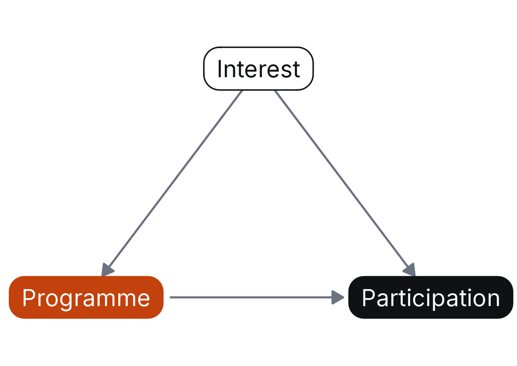

You can also draw DAGs in the browser at dagitty.net

# Three basic structures

01Foundations02Experiments03Observational studies04Advanced topics

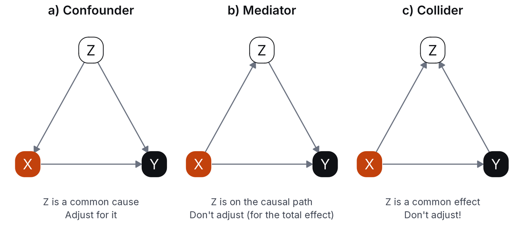

# Example: a confounder

01Foundations02Experiments03Observational studies04Advanced topics

- Does campaign **spending** increase a candidate’s **vote share**?
- Strong candidates (experienced, well known, scandal-free) **raise more money** *and* **win more votes**
- **Candidate quality** is a common cause: it opens the back door Spending ← Quality → Vote share
- Comparing big and small spenders mixes up the effect of money with the effect of quality, so the naive estimate is **too large**
- **Adjust for it:** measure quality (e.g. prior office held, previous vote share) and control for it

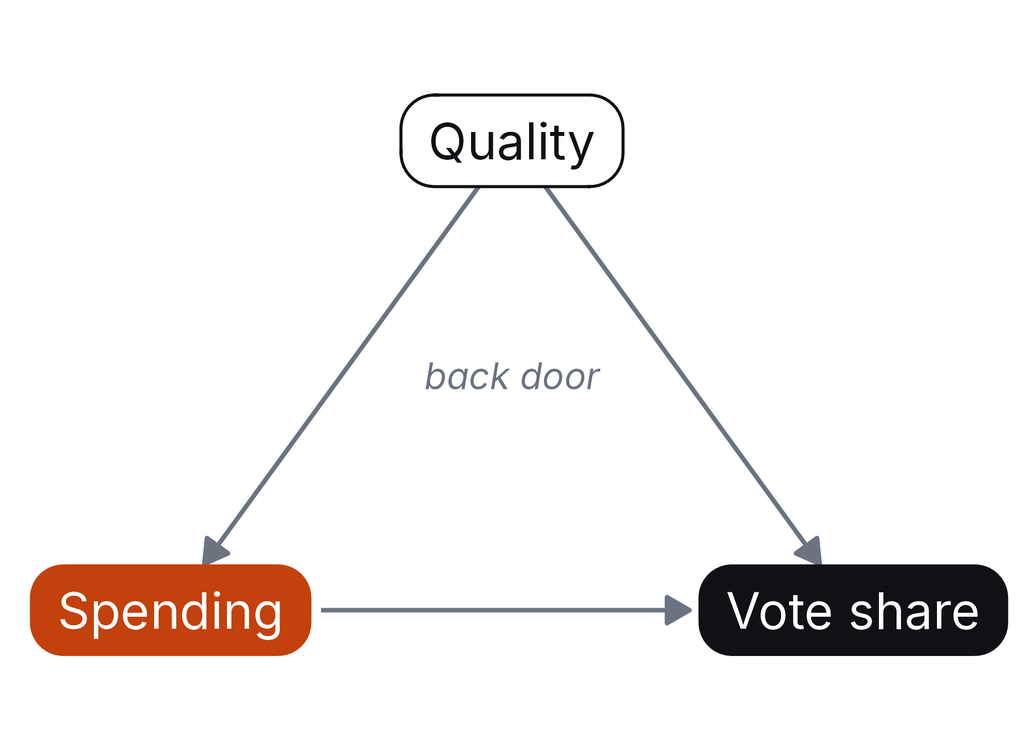

# Example: a mediator

01Foundations02Experiments03Observational studies04Advanced topics

- Does a **social pressure mailer** increase **turnout**? (the Gerber, Green & Larimer experiment from Part 2)
- The mailer works partly by raising people’s **intention to vote**
- **Intention** is a mediator: Mailer → Intention → Turnout is *part of* the effect we want
- If we control for intention, we compare people with the same intention and **remove the part of the effect that runs through it**: the estimate shrinks towards zero
- **Don’t adjust for it:** controlling for things the treatment affects causes *post-treatment bias*, even in an experiment

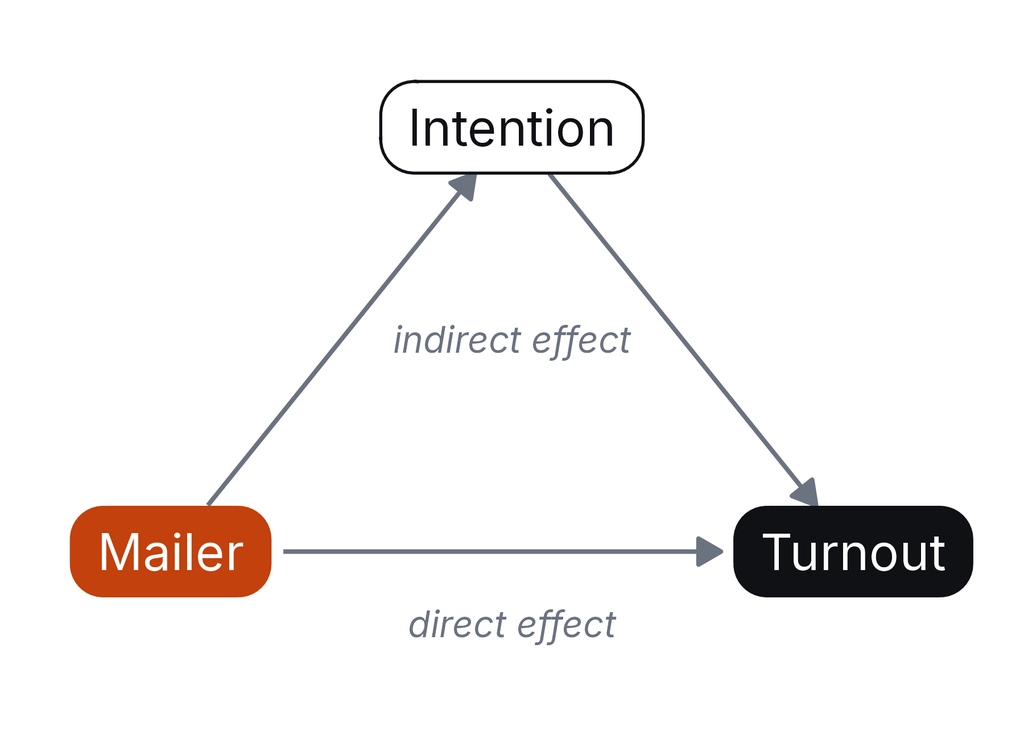

# Example: a collider

01Foundations02Experiments03Observational studies04Advanced topics

- Does **education** increase **political interest**? We test it with a survey
- But only some people **respond**: the educated *and* the politically interested are both more likely to answer
- **Responding** is a collider: Education → Responds ← Interest
- Analysing respondents only **conditions on the collider**: the less-educated people who answer are disproportionately the very interested ones
- This creates a **spurious negative** association, so we **underestimate** the effect
- **Don’t condition on it:** and watch for colliders hidden in **how the sample was selected**

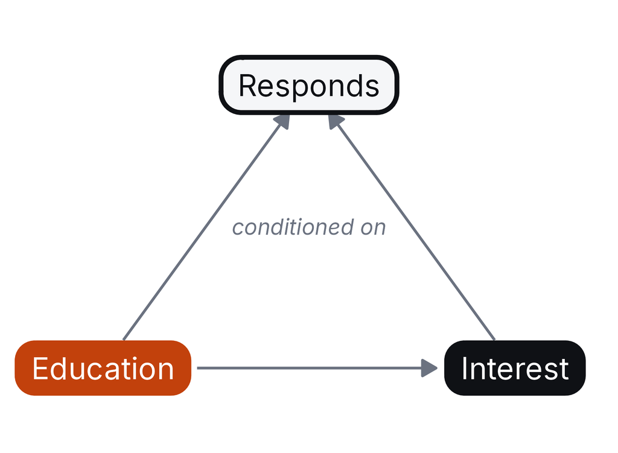

# Paths and back doors

01Foundations02Experiments03Observational studies04Advanced topics

- A **path** is any route between treatment $X$ (our $D$) and outcome $Y$, ignoring arrow direction
- **Front-door paths** follow the arrows all the way from $X$ to $Y$: these carry the causal effect we want
- **Back-door paths** start with an arrow *into* $X$: these create **spurious** association
  - e.g. $\text{Programme} \leftarrow \text{Interest} \rightarrow \text{Participation}$
- **Identification:** close all back-door paths, keep front-door paths open
  - Close a back door by **adjusting for** (controlling for) a variable on it
  - But a path through a **collider** is already closed, and adjusting for the collider **opens** it

# Letting dagitty do the work

01Foundations02Experiments03Observational studies04Advanced topics

```r
dag <- dagitty('dag {
  Programme -> Knowledge -> Participation
  Interest -> Programme
  Interest -> Participation
  Education -> Interest
  Education -> Participation
}')

adjustmentSets(dag, exposure = "Programme", outcome = "Participation")
```

```
{ Interest }
```

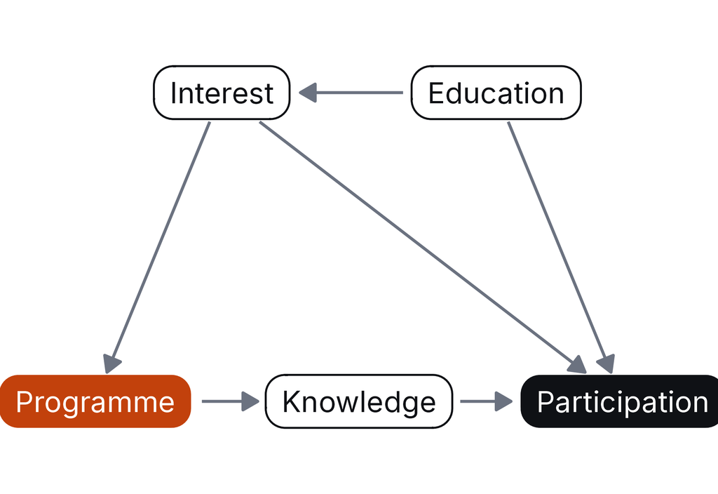

- `Knowledge` is a **mediator**: don’t adjust for it
- `Interest` sits on **both** back doors, so adjusting for it closes them:
  - Programme ← Interest → Participation
  - Programme ← Interest ← Education → Participation
- `Education` alone isn’t enough: Programme ← Interest → Participation stays open

# Confounding

01Foundations02Experiments03Observational studies04Advanced topics

- A **confounder** is a common cause of treatment and outcome
- It creates a back-door path, so treatment and outcome are associated even if there is **no causal effect**
- **Example:** Does a job training programme increase salary?
  - **Motivation** makes people more likely to take the training *and* to earn more
- Deciding what is a confounder needs **substantive knowledge**, not statistics
- If you can measure all the confounders, you can adjust for them…

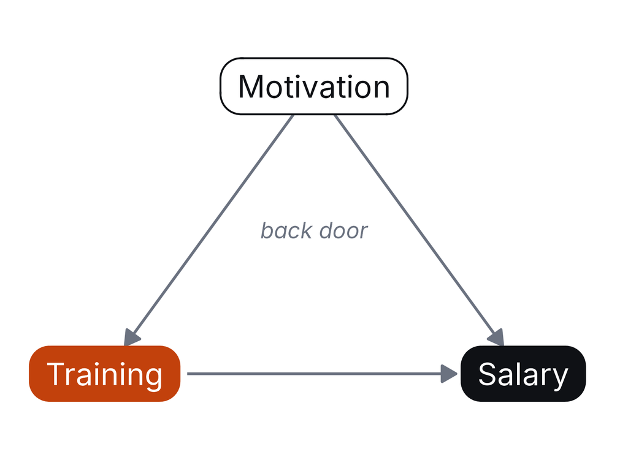

# Selection bias as a collider

01Foundations02Experiments03Observational studies04Advanced topics

- Suppose talent and charisma are **unrelated** in the population
- But politicians get elected if they have enough talent **plus** charisma
- Among **elected politicians**, what’s the relationship between talent and charisma?

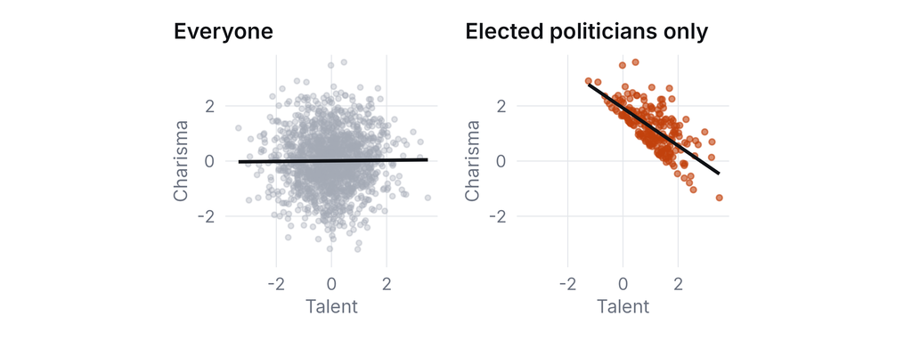

# Selection bias: conditioning on a collider

01Foundations02Experiments03Observational studies04Advanced topics

- $\text{Talent} \rightarrow \text{Elected} \leftarrow \text{Charisma}$: *Elected* is a **collider**
- Looking only at elected politicians **conditions on the collider** and creates a spurious negative correlation
- The same thing happens whenever **who ends up in our data** depends on treatment and outcome:
  - **Survival bias:** only observing units that survive (firms, regimes, parties)
  - **Non-response bias:** only observing people who answer the survey
  - **Attrition bias:** only observing people who stay in the study
  - **Publication bias:** only observing studies with significant results

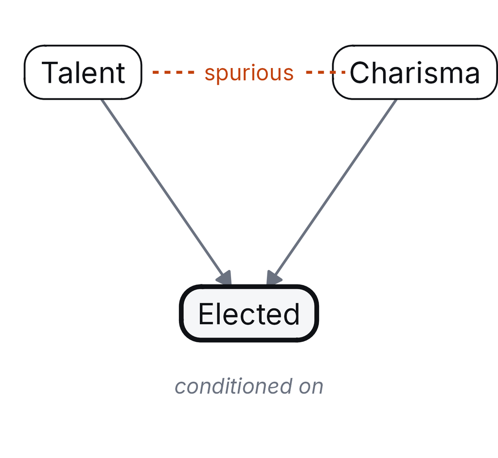

**Terminology:** economists often call the Part 1 term “selection bias” (usually caused by *confounding*); epidemiologists reserve it for this collider problem. Fix them differently: **adjust for confounders, don’t condition on colliders.**

# Selection on observables

01Foundations02Experiments03Observational studies04Advanced topics

- If we can **measure and adjust for** every confounder, we can recover the causal effect
  - **Regression** with controls
  - **Matching:** compare each treated unit with similar untreated units
- The key assumptions: **no unmeasured confounders** (*conditional independence*), plus **overlap**: comparable treated and untreated units exist for every combination of covariates
- That is a very strong assumption. Can you really measure “motivation” or “interest”?
- This is why social scientists look for **research designs** where something *other than* the units’ choices determines treatment

# Selection on unobservables…

01Foundations02Experiments03Observational studies04Advanced topics

[figure not shown]

# Activity: DAG your question (3 min)

01Foundations02Experiments03Observational studies04Advanced topics

Return to the causal question from this morning.

1. Draw a DAG with your **treatment**, **outcome** and the most important other variables
2. What are the **back-door paths**? What would you need to adjust for?
3. Is there anything you **shouldn’t** adjust for (mediators, colliders)?
4. Is there a confounder you **can’t measure**?

**Bonus:** Draw it with `dagitty` and run `adjustmentSets()`.

# Designs that approximate the experiment

01Foundations02Experiments03Observational studies04Advanced topics

When we can’t measure all confounders, we look for situations where some comparison can stand in for the **missing counterfactual**:

Difference-in-differences (DiD)

Compare *changes* over time between treated and control groups

Regression discontinuity (RD)

Compare units *just above and just below* a cutoff

Instrumental variables (IV)

Use something that *pushes* units into treatment but is otherwise unrelated to the outcome

For each design, ask: **what is the key assumption, and what could break it?**

# Difference-in-Differences (DiD)

01Foundations02Experiments03Observational studies04Advanced topics

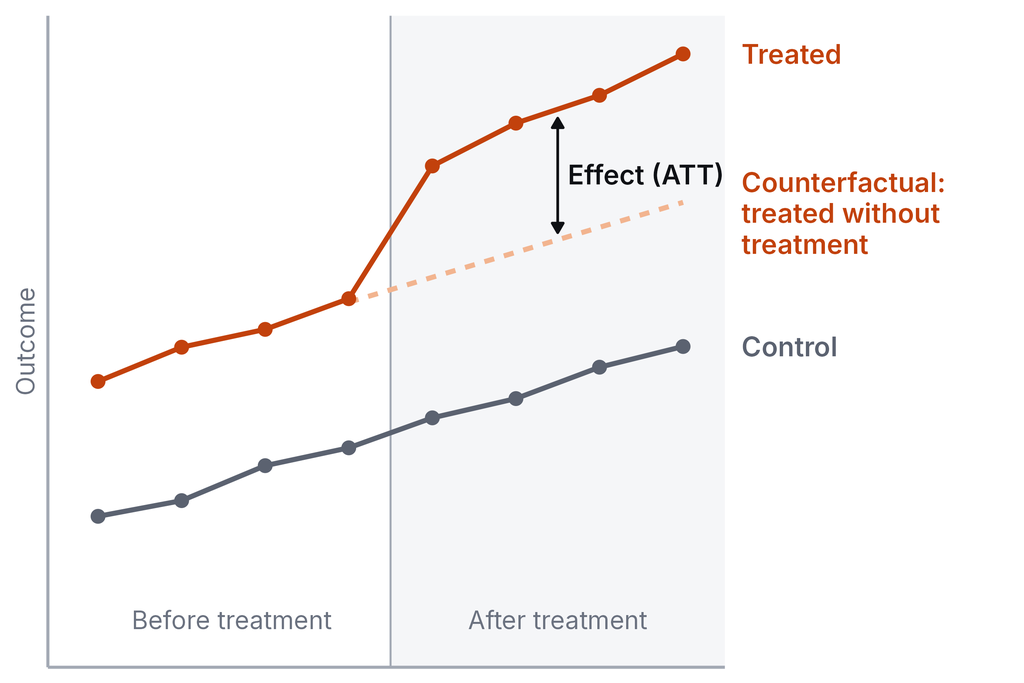

**Idea:** the control group’s *change* over time tells us what would have happened to the treated group without treatment

# DiD: the key assumption

01Foundations02Experiments03Observational studies04Advanced topics

- **Parallel trends:** without treatment, treated and control units would have followed the **same trend**
  - The *levels* can differ; the *trends* must match
  - Anything **fixed** about a unit cancels out, even if unobserved
- **Also needed:**
  - **No anticipation:** units don’t change behaviour before treatment begins
  - **No spillovers:** treatment doesn’t affect control units
- **Estimand:** usually the **ATT**
- **What could break it?** Something else that changes at the same time, only for the treated group

# DiD example: “LIBERATE” tweets

01Foundations02Experiments03Observational studies04Advanced topics

In April 2020, Donald Trump tweeted calls to “LIBERATE” **Michigan, Minnesota and Virginia**, three states under COVID-19 lockdowns. Did this reduce compliance with lockdown?

- **Treatment:** counties in the three targeted states
- **Control:** counties in other states
- **Outcome:** Google mobility outside the home minus time at home (higher = less compliance), before and after 17 April
- **Parallel trends:** without the tweets, mobility would have changed the same way in targeted and other states
- **Threats?** Michigan’s “Operation Gridlock” protest (15 April)? Trump’s reopening guidelines (16 April)? Easter weekend in the pre-period? Spillovers to neighbouring states?

In **Lab 2** we’ll apply DiD to a classic case: New Jersey’s 1992 minimum wage increase.

# Regression Discontinuity (RD)

01Foundations02Experiments03Observational studies04Advanced topics

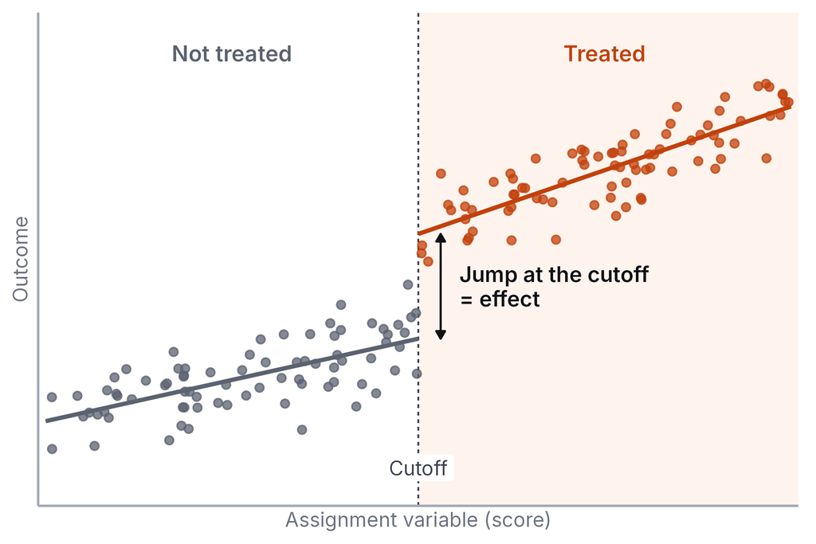

**Idea:** many rules assign treatment based on a **cutoff**. Units just either side of it are very similar, except for treatment.

# RD: the key assumption

01Foundations02Experiments03Observational studies04Advanced topics

- **Continuity:** without treatment, outcomes would change **smoothly** through the cutoff
  - So any **jump** at the cutoff is caused by the treatment
- **No manipulation:** units can’t precisely sort themselves to one side of the cutoff
  - Check: is there a suspicious bunching of units just above the cutoff?
- **Estimand:** a **local** effect, for units **near the cutoff**
- **Example** (Lee 2008): Does being the incumbent party help you win the next election?
  - Compare US House districts where a party **barely won** vs. **barely lost**
  - Close elections are “as good as random”

# Instrumental Variables (IV)

01Foundations02Experiments03Observational studies04Advanced topics

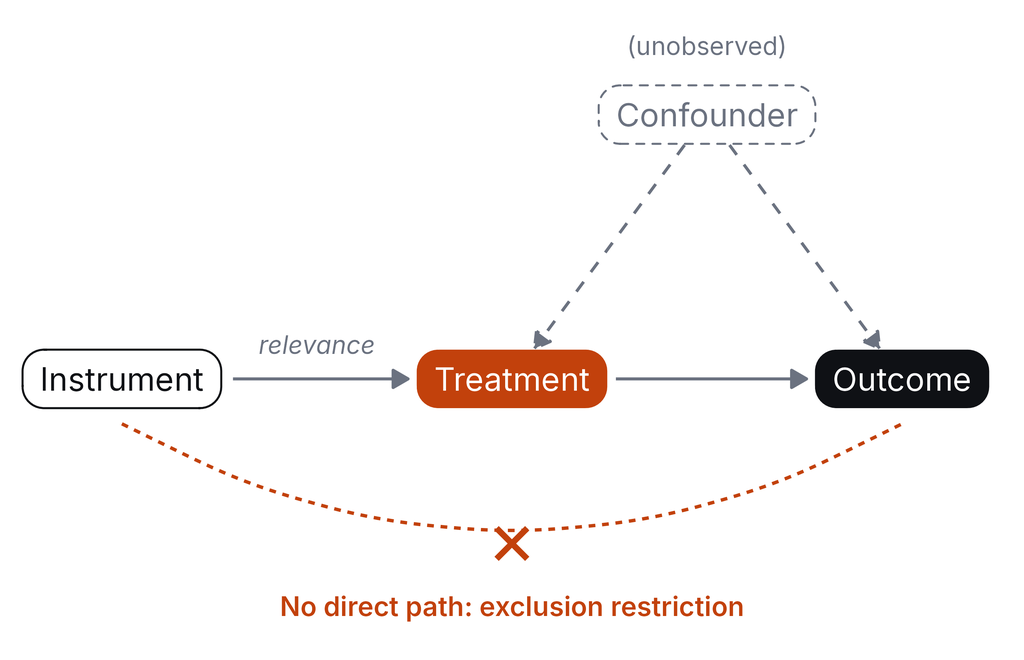

**Idea:** find something (the **instrument**) that pushes units into treatment but is unrelated to the outcome in any other way

# IV: the key assumptions

01Foundations02Experiments03Observational studies04Advanced topics

- **Relevance:** the instrument actually affects treatment (we can check this)
- **Independence:** the instrument is as good as randomly assigned
- **Exclusion restriction:** the instrument affects the outcome **only through** the treatment (we can’t check this!)
- **Monotonicity:** the instrument doesn’t push anyone *out of* treatment (no “defiers”)
- **Estimand:** the **LATE**, the effect for **compliers** (units whose treatment is changed by the instrument)
- Remember the random **invitation** from Lab 1? That was an instrument: $\text{CACE} = \text{ITT} / \text{compliance}$

# IV example: College and earnings

01Foundations02Experiments03Observational studies04Advanced topics

Does more schooling increase earnings? Ability, motivation and family background affect both.

- Card (1993) uses **growing up near a college** as an instrument for education
  - **Treatment:** years of schooling
  - **Instrument:** proximity to a college
  - **Outcome:** earnings
- **Relevance:** living nearby makes college cheaper and more likely ✅
- **Exclusion:** does proximity affect earnings in any *other* way?
  - Colleges are in cities. Cities have better jobs, better schools, different families…

# Summary: Designs

01Foundations02Experiments03Observational studies04Advanced topics

| Design | Comparison | Key assumption | Estimand | What could break it? |
| --- | --- | --- | --- | --- |
| **Experiment** | Randomized treatment vs. control | Random assignment (+ compliance, no attrition) | ATE | Noncompliance, attrition, spillovers |
| **Selection on observables** | Treated vs. similar untreated units | No unmeasured confounders | ATE / ATT | Any unmeasured confounder |
| **DiD** | Change in treated vs. change in control | Parallel trends | ATT | Other treated-group-specific shocks |
| **RD** | Just above vs. just below a cutoff | Continuity at the cutoff | Local effect at the cutoff | Sorting / manipulation |
| **IV** | Units pushed into treatment by the instrument | Exclusion restriction (+ relevance, monotonicity) | LATE (compliers) | Instrument affects outcome directly |

# Lab 2: Difference-in-Differences

01Foundations02Experiments03Observational studies04Advanced topics

Open `code/lab2_did.qmd` from the [GitHub repository](https://github.com/z-dickson/my580-causal-inference) in RStudio.

**Did New Jersey’s 1992 minimum wage increase ($4.25 → $5.05) reduce employment?** (Card and Krueger 1994)

0. *Warm-up:* DAG the design with `dagitty`
1. Build the **treatment** (New Jersey) and **post** indicators
2. Check that the treatment happened: did **wages** rise?
3. Estimate the **2×2 DiD**: by hand, with regression, and with **two-way fixed effects**
4. Use **high-wage New Jersey restaurants** as a second control group
5. *Simulation:* what an **event study** adds when we have more periods

Data: [Card & Krueger’s survey](https://davidcard.berkeley.edu/data_sets.html) of 410 fast-food restaurants in New Jersey and Pennsylvania, February and November 1992. We’ll regroup at 14:15.

# The DiD regression

01Foundations02Experiments03Observational studies04Advanced topics

$$Y_{it} = \alpha_i + \lambda_t + \delta \, D_{it} + \varepsilon_{it}$$

- $Y_{it}$: FTE employment in restaurant $i$ in survey wave $t$
- $\alpha_i$: **restaurant fixed effects**, absorbing everything fixed about a restaurant
- $\lambda_t$: **wave fixed effects**, absorbing everything that affects all restaurants in a given wave
- $D_{it} = \text{NJ}_i \times \text{post}_t$: 1 for New Jersey restaurants after the increase
- $\delta$: the DiD estimate of the **ATT**

```r
feols(fte ~ under_treatment | store_id + wave, data = data, vcov = ~ store_id)
```

Treatment is assigned at the **state** level, but with one treated and one control state we can’t cluster by state. That’s why the comparison **within** New Jersey matters.

# Summary: Observational studies

01Foundations02Experiments03Observational studies04Advanced topics

- Without randomization, we must model **why** units were treated
- **DAGs** make our assumptions explicit: close back doors; don’t adjust for mediators or colliders
- **Selection on observables** requires measuring *all* confounders, which is rarely credible on its own
- **DiD, RD and IV** find comparisons that can stand in for the missing counterfactual, each under its own assumption (for DiD, parallel trends, not random assignment)
- No design is assumption-free. The question is which assumptions are **most plausible** for your case.

# 10 minute break

# Part 4 Advanced Topics

01Foundations02Experiments03Observational studies04Advanced topics

A short tour of where the field has gone

# Staggered DiD and the problem with TWFE

01Foundations02Experiments03Observational studies04Advanced topics

- Often units get treated at **different times** (e.g. states adopting a policy in different years)
- The standard two-way fixed effects (TWFE) regression then uses **already-treated** units as controls for **later-treated** ones
- If effects **change over time**, TWFE can be badly biased, and can even get the sign wrong (Goodman-Bacon 2021)
- **Solutions:** estimators that only make “clean” comparisons
  - Callaway and Sant’Anna (2021): estimate group-time ATTs, then aggregate
  - Also Sun & Abraham; de Chaisemartin & D’Haultfœuille; Borusyak, Jaravel & Spiess
- **Takeaway:** with staggered timing, don’t just run TWFE

# Synthetic control

01Foundations02Experiments03Observational studies04Advanced topics

- What if there’s only **one** treated unit (a country, a state, a city)?
- **Idea:** build a “synthetic” control as a **weighted average of untreated units** that matches the treated unit’s **pre-treatment** trajectory
- **Classic example** (Abadie, Diamond, and Hainmueller 2010): California’s 1988 tobacco control programme
  - “Synthetic California” built from other US states
  - The gap after 1988 is the estimated effect
- Inference by **placebo**: pretend each control unit was treated. Is the real effect unusual?
- Related: **matrix completion** methods (Athey et al. 2021)

# Sensitivity analysis

01Foundations02Experiments03Observational studies04Advanced topics

- We can rarely rule out **all** unmeasured confounding
- So instead ask: **how strong would an unobserved confounder have to be to overturn my result?**
- Cinelli and Hazlett (2020): express this **relative to observed covariates**
  - e.g. “a confounder would need to be 3× as strong as education to explain away the effect”
  - R package: `sensemakr`
- This shifts the debate from “is there confounding?” (always yes) to “**is it plausible that there’s this much?**”

# Heterogeneous effects and machine learning

01Foundations02Experiments03Observational studies04Advanced topics

- The ATE is an **average**. Effects can differ across people: the **CATE**, $E[Y_i(1) - Y_i(0) \mid X_i = x]$
- **Causal forests** (Wager and Athey 2018): adapt random forests to find *who* responds most to treatment
- **Double/debiased machine learning** (Chernozhukov et al. 2018): use ML to flexibly adjust for many covariates, while keeping valid inference for the treatment effect
- **But:** ML helps with **estimation**, not **identification**
  - It can’t fix an unmeasured confounder
  - Design still comes first

# Interference and mediation

01Foundations02Experiments03Observational studies04Advanced topics

- **Interference (SUTVA violations):** one unit’s treatment affects others’ outcomes
  - Canvassing one voter affects their housemates; vaccinating one person protects others
  - Solutions: randomize at the **cluster** level, or model the spillovers directly
- **Mediation:** *how* does a treatment work?
  - Total effect = direct effect + indirect effect through a mediator
  - Even in an experiment, the mediator is **not randomized**, so we need strong extra assumptions (Imai et al. 2011)

# Where to go next

01Foundations02Experiments03Observational studies04Advanced topics

- **Design before data:** decide your identification strategy *before* you run regressions
- **Pre-registration:** write down your design and analysis plan in advance
- **Transparency:** state your assumptions (DAGs help) and test the testable ones
- **Read:**
  - Huntington-Klein, [*The Effect*](https://theeffectbook.net): Ch. 21 (Partial Identification), 22 (A Gallery of Rogues), 23 (Under the Rug)
  - Cunningham, [*Causal Inference: The Mixtape*](https://mixtape.scunning.com)

# Summary of the Day

- **Foundations:** causal effects compare potential outcomes; we only see one, so **naive comparisons = effect + selection bias**
- **Experiments:** randomization eliminates selection bias on average. This is the **experimental ideal**.
- **Observational studies:** DAGs make assumptions explicit; DiD, RD and IV approximate the experiment under **design-specific assumptions**
- **Advanced topics:** the toolkit keeps growing, but **design still comes first**

# Additional Resources

- [The Effect: An Introduction to Research Design and Causality](https://theeffectbook.net/), Nick Huntington-Klein
- [Causal Inference: The Mixtape](https://mixtape.scunning.com/), Scott Cunningham
- [Causal Inference: What If](https://miguelhernan.org/whatifbook), Miguel Hernán & James Robins
- [(Mostly Clinical) Epidemiology with R](https://bookdown.org/jbrophy115/bookdown-clinepi/), James Brophy
- *Field Experiments: Design, Analysis, and Interpretation*, Alan Gerber & Donald Green
- Course materials: github.com/z-dickson/my580-causal-inference

# Questions?

- Feel free to ask any questions you have about the material we’ve covered today.

# Thank you!

Reach out if you have further questions: z.dickson@lse.ac.uk

# References

Abadie, Alberto, Alexis Diamond, and Jens Hainmueller. 2010. “Synthetic Control Methods for Comparative Case Studies: Estimating the Effect of California’s Tobacco Control Program.” *Journal of the American Statistical Association* 105 (490): 493–505.

Athey, Susan, Mohsen Bayati, Nikolay Doudchenko, Guido Imbens, and Khashayar Khosravi. 2021. “Matrix Completion Methods for Causal Panel Data Models.” *Journal of the American Statistical Association* 116 (536): 1716–30.

Callaway, Brantly, and Pedro H. C. Sant’Anna. 2021. “Difference-in-Differences with Multiple Time Periods.” *Journal of Econometrics* 225 (2): 200–230.

Card, David. 1993. “Using Geographic Variation in College Proximity to Estimate the Return to Schooling.” NBER Working Paper 4483. National Bureau of Economic Research.

Card, David, and Alan B. Krueger. 1994. “Minimum Wages and Employment: A Case Study of the Fast-Food Industry in New Jersey and Pennsylvania.” *American Economic Review* 84 (4): 772–93.

Chernozhukov, Victor, Denis Chetverikov, Mert Demirer, Esther Duflo, Christian Hansen, Whitney Newey, and James Robins. 2018. “Double/Debiased Machine Learning for Treatment and Structural Parameters.” *The Econometrics Journal* 21 (1): C1–68.

Cinelli, Carlos, and Chad Hazlett. 2020. “Making Sense of Sensitivity: Extending Omitted Variable Bias.” *Journal of the Royal Statistical Society Series B: Statistical Methodology* 82 (1): 39–67.

Gerber, Alan S., Donald P. Green, and Christopher W. Larimer. 2008. “Social Pressure and Voter Turnout: Evidence from a Large-Scale Field Experiment.” *American Political Science Review* 102 (1): 33–48.

Goodman-Bacon, Andrew. 2021. “Difference-in-Differences with Variation in Treatment Timing.” *Journal of Econometrics* 225 (2): 254–77.

Imai, Kosuke, Luke Keele, Dustin Tingley, and Teppei Yamamoto. 2011. “Unpacking the Black Box of Causality: Learning about Causal Mechanisms from Experimental and Observational Studies.” *American Political Science Review* 105 (4): 765–89.

Lee, David S. 2008. “Randomized Experiments from Non-Random Selection in U.S. House Elections.” *Journal of Econometrics* 142 (2): 675–97.

Wager, Stefan, and Susan Athey. 2018. “Estimation and Inference of Heterogeneous Treatment Effects Using Random Forests.” *Journal of the American Statistical Association* 113 (523): 1228–42.